# Major

Porter Bischoff

### *Major*

Alright, awesome. Data is loaded, and MDS is ready to be run. We created this for-loop that will allow us to get the plots of the MDS data according to gender and whatever grouping of questions we are exploring particularly.

Let’s check out the relationship in Science Identity questions and majors.

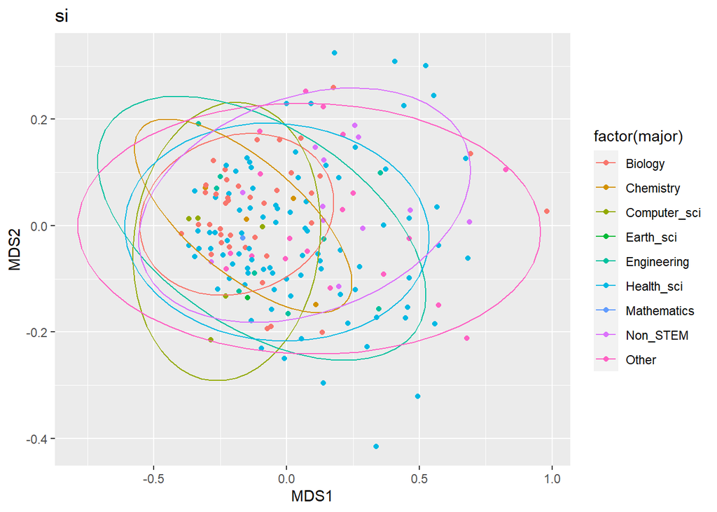

```r
major_plots[[1]]
```

Well, that is kind of a mess. Let’s run the Adonis test to see if there is a significant difference in Science Identity answers versus majors.

```r
adonis(si ~ demo$major)
```

```
##
## Call:
## adonis(formula = si ~ demo$major)
##
## Permutation: free
## Number of permutations: 999
##
## Terms added sequentially (first to last)
##
##             Df SumsOfSqs  MeanSqs F.Model      R2 Pr(>F)
## demo$major   8    0.8771 0.109636  3.6695 0.08833  0.002 **
## Residuals  303    9.0528 0.029877         0.91167
## Total      311    9.9299                  1.00000
## ---
## Signif. codes:  0 '***' 0.001 '**' 0.01 '*' 0.05 '.' 0.1 ' ' 1
```

Well gosh, check that out. We have a significant difference here. We will *mark that down for later analysis*.

Next, lets measure significance in difference in Career Motivation and majors. The same Adonis test is run on that.

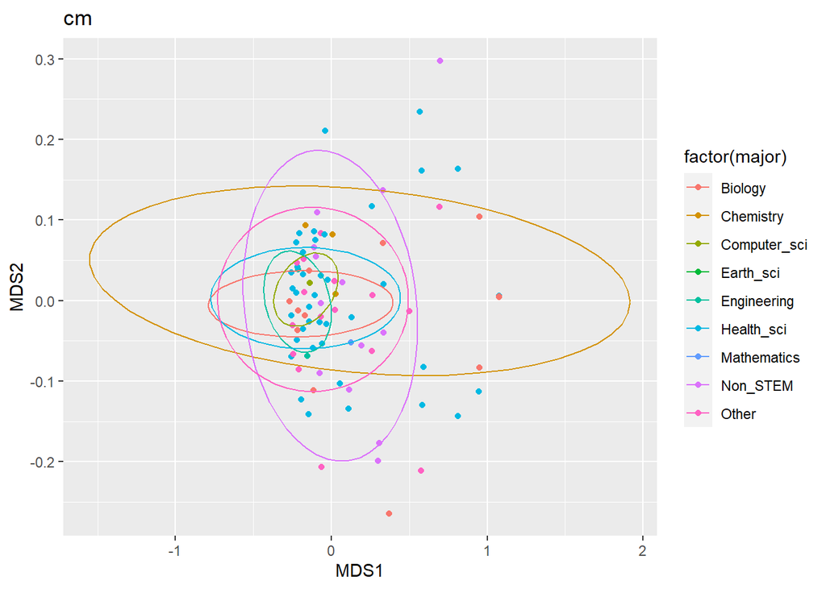

```r
major_plots[[2]]
```

```r
adonis(cm ~ demo$major)
```

```
##
## Call:
## adonis(formula = cm ~ demo$major)
##
## Permutation: free
## Number of permutations: 999
##
## Terms added sequentially (first to last)
##
##             Df SumsOfSqs  MeanSqs F.Model      R2 Pr(>F)
## demo$major   8    0.4423 0.055290  1.0885 0.02794  0.367
## Residuals  303   15.3905 0.050794         0.97206
## Total      311   15.8329                  1.00000
```

This shows that there is no significance.

Now, we will measure significance in difference in Intrinsic Motivation and majors, with an Adonis being run.

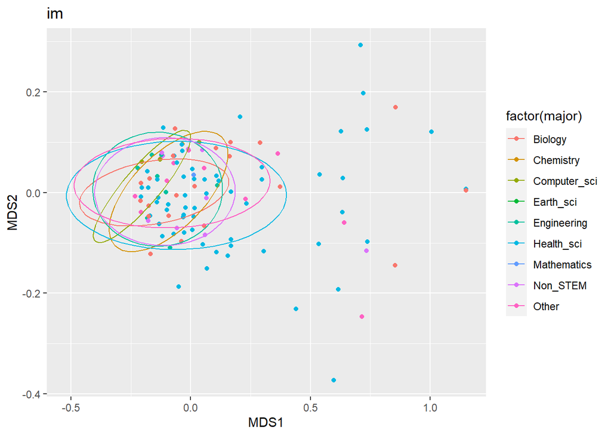

```r
major_plots[[3]]
```

```r
adonis(im ~ demo$major)
```

```
##
## Call:
## adonis(formula = im ~ demo$major)
##
## Permutation: free
## Number of permutations: 999
##
## Terms added sequentially (first to last)
##
##             Df SumsOfSqs  MeanSqs F.Model      R2 Pr(>F)
## demo$major   8    0.3414 0.042676  1.5266 0.03874  0.161
## Residuals  303    8.4705 0.027955         0.96126
## Total      311    8.8119                  1.00000
```

No significance here, either.

Next, Self-Determination and majors.

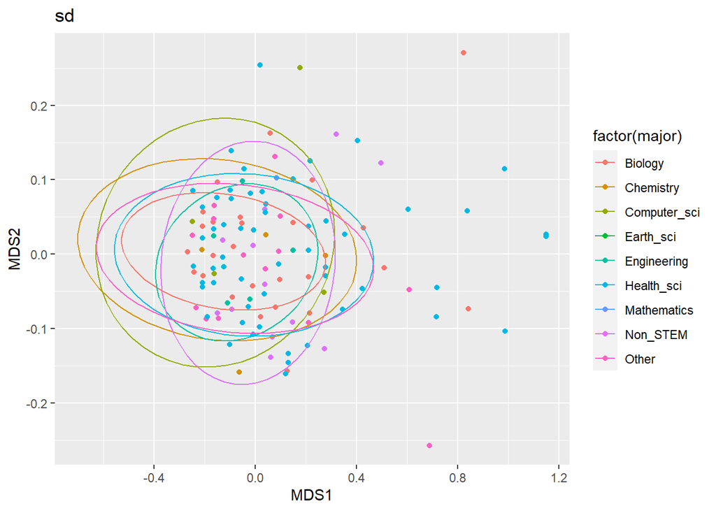

```r
major_plots[[4]]
```

```r
adonis(sd ~ demo$major)
```

```
##
## Call:
## adonis(formula = sd ~ demo$major)
##
## Permutation: free
## Number of permutations: 999
##
## Terms added sequentially (first to last)
##
##             Df SumsOfSqs  MeanSqs F.Model      R2 Pr(>F)
## demo$major   8    0.1709 0.021358 0.86911 0.02243  0.526
## Residuals  303    7.4460 0.024574         0.97757
## Total      311    7.6168                  1.00000
```

Again, not significant.

Here is Self-Efficacy and majors.

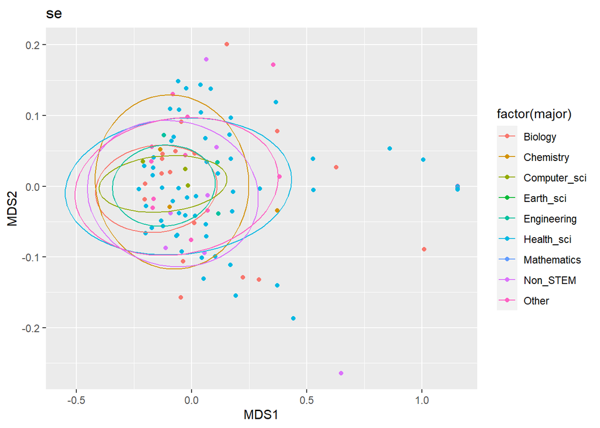

```r
major_plots[[5]]
```

```r
adonis(se ~ demo$major)
```

```
##
## Call:
## adonis(formula = se ~ demo$major)
##
## Permutation: free
## Number of permutations: 999
##
## Terms added sequentially (first to last)
##
##             Df SumsOfSqs  MeanSqs F.Model      R2 Pr(>F)
## demo$major   8    0.3163 0.039543   1.463 0.03719  0.174
## Residuals  303    8.1896 0.027028         0.96281
## Total      311    8.5059                  1.00000
```

This is not significant.

This is Grade Motivation and majors.

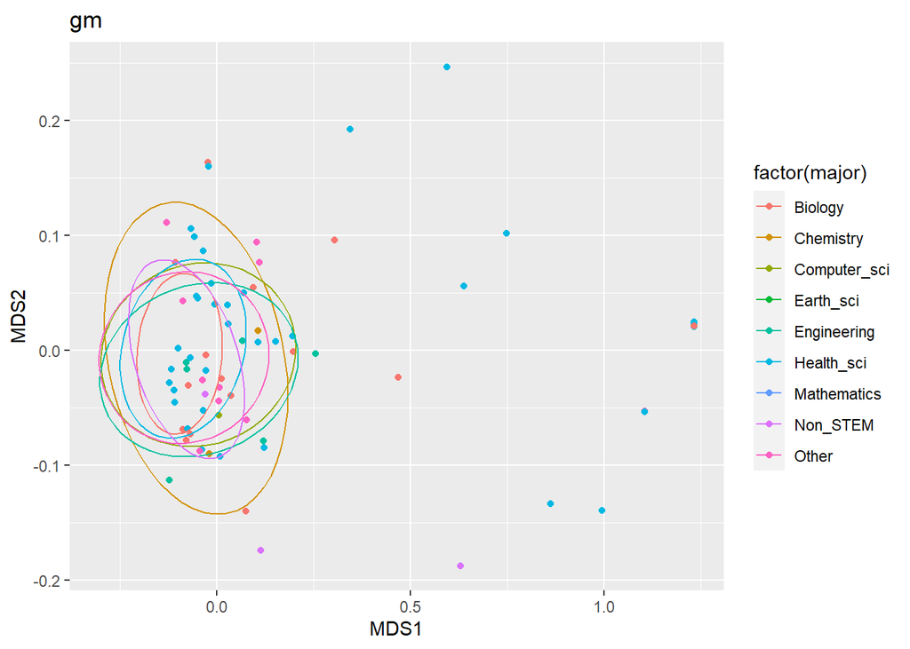

```r
major_plots[[6]]
```

```r
adonis(gm ~ demo$major)
```

```
##
## Call:
## adonis(formula = gm ~ demo$major)
##
## Permutation: free
## Number of permutations: 999
##
## Terms added sequentially (first to last)
##
##             Df SumsOfSqs  MeanSqs F.Model      R2 Pr(>F)
## demo$major   8    0.0883 0.011043 0.49189 0.01282  0.813
## Residuals  303    6.8025 0.022451         0.98718
## Total      311    6.8909                  1.00000
```

This is not significant.

Here is Science Competency and major.

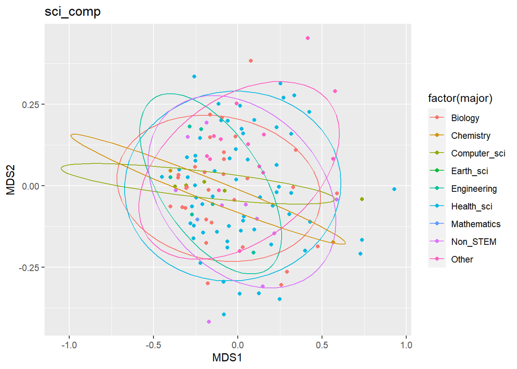

```r
major_plots[[7]]
```

```r
adonis(sci_comp ~ demo$major)
```

```
##
## Call:
## adonis(formula = sci_comp ~ demo$major)
##
## Permutation: free
## Number of permutations: 999
##
## Terms added sequentially (first to last)
##
##             Df SumsOfSqs  MeanSqs F.Model      R2 Pr(>F)
## demo$major   8    0.3478 0.043476  1.2599 0.03219  0.252
## Residuals  303   10.4562 0.034509         0.96781
## Total      311   10.8040                  1.00000
```

This one is not significant, either.

Now, Personal Communal Orientation and majors.

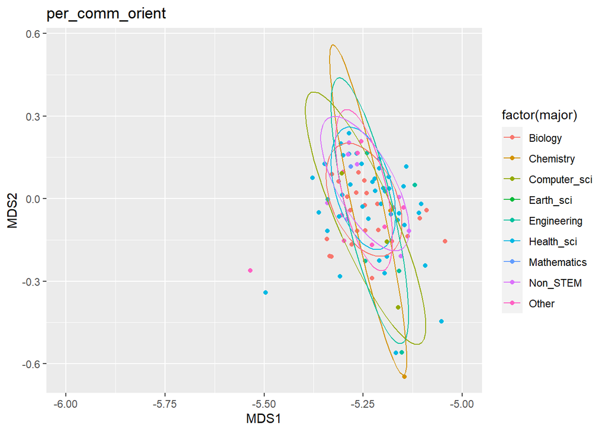

```r
major_plots[[8]] +
  coord_cartesian(xlim = c(-6,-5))
```

```r
adonis(per_comm_orient ~ demo$major)
```

```
##
## Call:
## adonis(formula = per_comm_orient ~ demo$major)
##
## Permutation: free
## Number of permutations: 999
##
## Terms added sequentially (first to last)
##
##             Df SumsOfSqs   MeanSqs F.Model      R2 Pr(>F)
## demo$major   8   0.10277 0.0128465  1.4734 0.03745  0.125
## Residuals  303   2.64181 0.0087188         0.96255
## Total      311   2.74458                   1.00000
```

This one is not significant.

Lastly, lets explore Science Communal Orientation and majors.

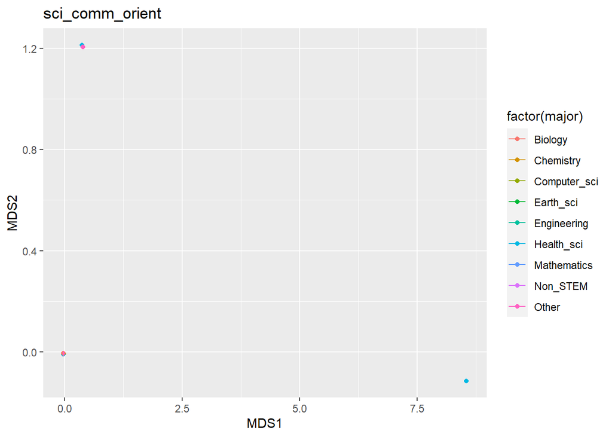

```r
major_plots[[9]]
```

Well heck, that didn’t work. Let’s run a different type of MDS and try that.

```r
zerorows <- which(rowSums(sci_comm_orient) == 0)

temp <- sci_comm_orient[-zerorows, ]

dec <- decorana(temp, mk=2)
dec <- summary(dec)
```

```
##
## Call:
## decorana(veg = temp, mk = 2)
##
## Detrended correspondence analysis with 10 segments.
## Rescaling of axes with 4 iterations.
##
##                     DCA1     DCA2     DCA3      DCA4
## Eigenvalues     0.004290 0.001836 0.001720 0.0039070
## Decorana values 0.004291 0.001800 0.001645 0.0005258
## Axis lengths    0.523513 0.335258 0.288489 0.5307106
```

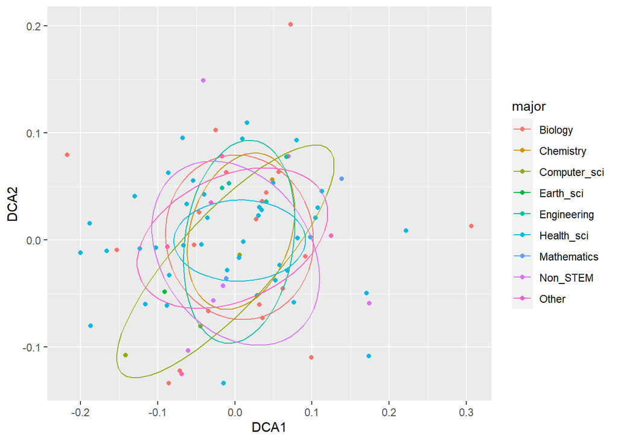

```r
dec %>% as.matrix()
x=dec$site.scores[,1]
y=dec$site.scores[,2]

demo_DCA <- demo[-zerorows,]

demo_DCA$DCA1 <- x
demo_DCA$DCA2 <- y

demo_DCA %>% ggplot(mapping= aes(x=DCA1, y=DCA2,color=major)) +
  geom_point()+
  stat_ellipse()
```

Now, let’s see if it is significant.

```r
adonis(sci_comm_orient ~ demo$major)
```

```
##
## Call:
## adonis(formula = sci_comm_orient ~ demo$major)
##
## Permutation: free
## Number of permutations: 999
##
## Terms added sequentially (first to last)
##
##             Df SumsOfSqs  MeanSqs F.Model      R2 Pr(>F)
## demo$major   8    0.0980 0.012255 0.82608 0.02135    0.5
## Residuals  303    4.4949 0.014835         0.97865
## Total      311    4.5929                  1.00000
```

Lo and behold, this is not significant.

Now, what does this all mean? All of the differences in the aspects of the survey and majors were not significant except for the Science Identity questions. This tells us that in our sample, there is a difference in how different majors answer Science Identity. To understand this, further model analysis needs to be run, something that will be run in later explorations of this data set.